# FIRST Robotics Competition: How Much Better Are Experienced Teams?

11/22/2020

## Road Map

- Background
- Data Scraping
- Data Manipulation
- Data Analysis
  1. Performance Within A Season
  2. Events Attended in a Season and Performance
  3. Performance Over Multiple Seasons
  4. Top Performing Teams of All Time
  5. Performance of Longest Competing Teams
- Conclusion

## Background

The FIRST Robotics Competition (FRC) is a competition where teams build a robot for 6ish weeks, then compete in one or more events to try to secure a spot in the championship. In 2019, there were over 3800 active teams competing at over 160 events worldwide.

[figure not shown]

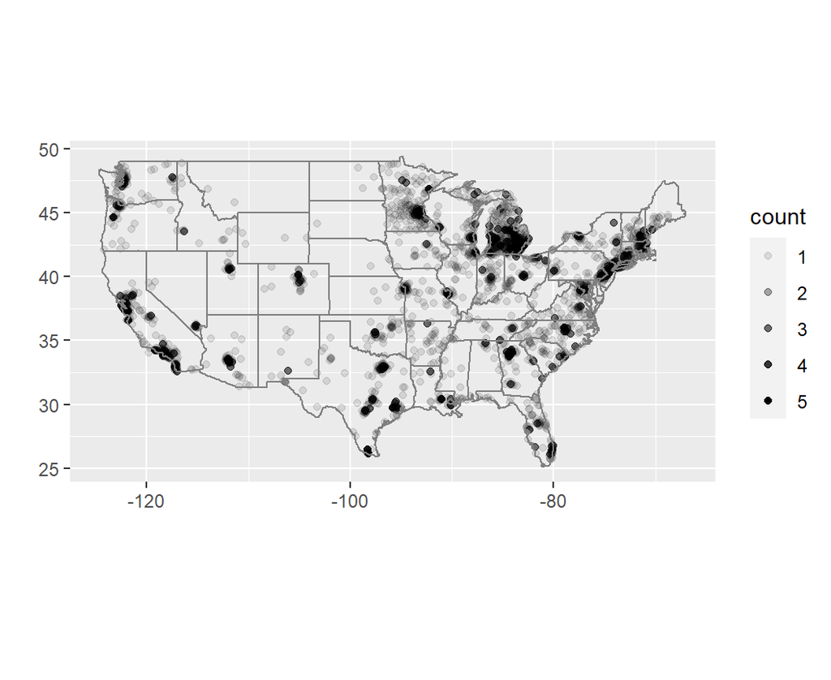

## Data Scraping

Data Sources

- The Blue Alliance
- Zip code data from erichurst on GitHub

## Data Scraping

The Blue Alliance API Endpoints

- `/events/{year}`
- `/event/{event_name}/matches/simple`
- `/teams/{page}`
- `/team/{team_key}/years_participated`

## Data Scraping

### Raw Data

| alliances.blue.team_keys |
| --- |
| frc4607, frc3102, frc3184 |

### Cleaned Data

| blue_alliance_1 | blue_alliance_2 | blue_alliance_3 |
| --- | --- | --- |
| frc4607 | frc3102 | frc3184 |

## Data Scraping

```
df %>%
  unnest(alliances.blue.team_keys) %>%
  group_by(key) %>%
  mutate(col = seq_along(key)) %>%
  spread(key = col,
         value = alliances.blue.team_keys) %>%
  { if ("1" %in% colnames(.)) rename(., blue_alliance_1 = `1`)
    else mutate(., blue_alliance_1 = NA) } %>%
  { if ("2" %in% colnames(.)) rename(., blue_alliance_2 = `2`)
    else mutate(., blue_alliance_2 = NA) } %>%
  { if ("3" %in% colnames(.)) rename(., blue_alliance_3 = `3`)
    else mutate(., blue_alliance_3 = NA) } %>%
  { if ("4" %in% colnames(.)) rename(., blue_alliance_4 = `4`)
    else mutate(., blue_alliance_4 = NA) }
```

## Data Manipulation

```
matches <- readRDS("matches.rds") %>%
  mutate(week = case_when(
    event_type == "district_championship_division" ~ "dcmpd",
    event_type == "district_championship" ~ "dcmp",
    event_type == "championship_division" ~ "cmpd",
    event_type == "championship_finals" ~ "cmpf",
    event_type == "festival_of_champions" ~ "foc",
    TRUE ~ as.character(week)
  )) %>%
  mutate(week = factor(week, c("0", "1", "2", "3", "4", "5", "6", "7",
                               "dcmpd", "dcmp", "cmpd", "cmpf", "foc")))
```

## Data Manipulation

```
for (yr in years) {
  x <- team_avg_by_year %>%
    filter(year == yr)
  # ecdf = Empirical Cumulative Distribution Function
  x$percentile <- ecdf(x$avg_score)(x$avg_score) * 100

  team_percentile_by_year <- bind_rows(team_percentile_by_year, x) %>%
    arrange(team_num)
}
```

## Data Analysis

Our goal is to examine how the experience of a team impacts their performance. We will do this by examining the following trends:

- How teams perform as the season progresses
- How do the most active teams within a season perform
- How does a team perform over multiple seasons
- How do the most experienced teams perform

## 1. Performance Within A Season

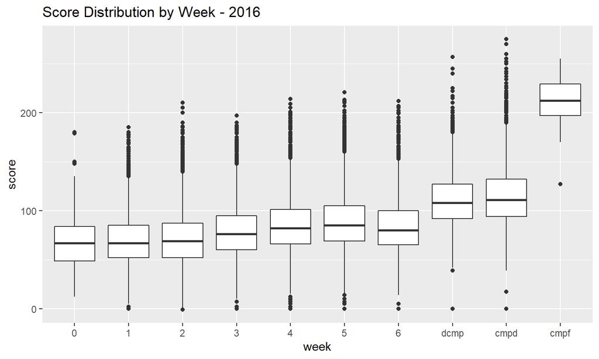

## 2. Events Attended in a Season and Performance

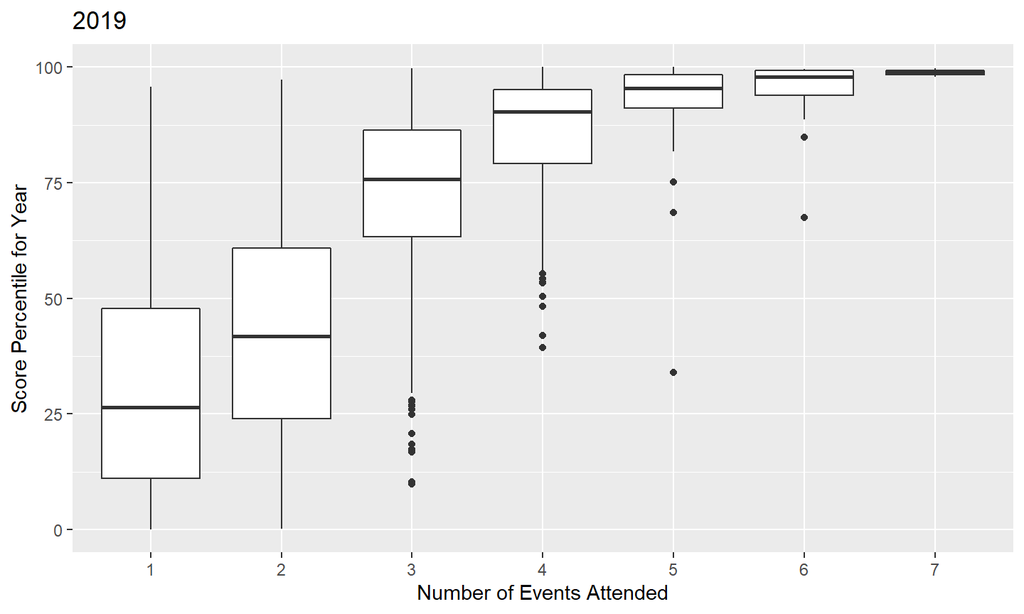

## 2. Events Attended in a Season and Performance

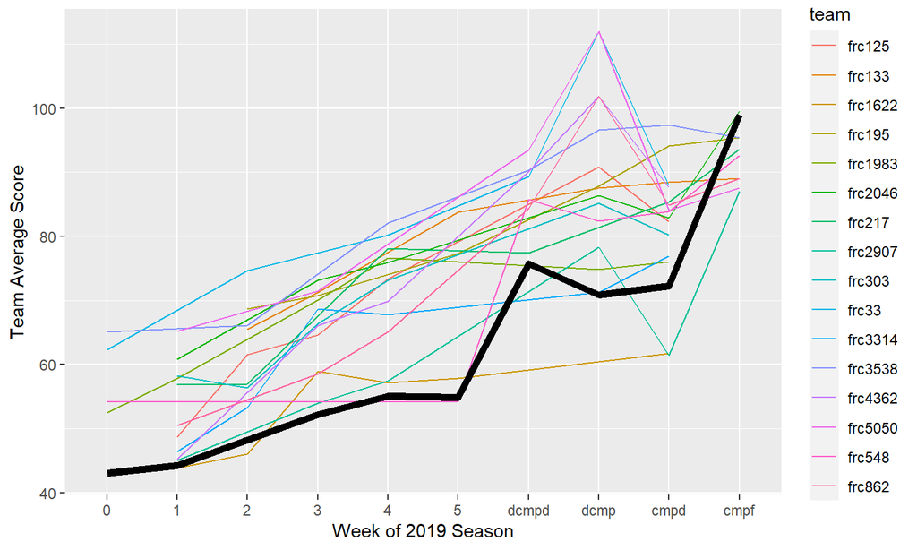

## 3. Performance Over Multiple Seasons

Score Difference Each Year

| Year | Average Score |
| --- | --- |
| 2002 | 29.92 |
| 2003 | 48.99 |
| 2004 | 59.85 |
| 2005 | 28.25 |
| 2006 | 35.21 |
| 2007 | 30.06 |
| 2008 | 42.88 |
| 2009 | 56.69 |
| 2010 | 4.08 |

| Year | Average Score |
| --- | --- |
| 2011 | 38.12 |
| 2012 | 25.05 |
| 2013 | 64.81 |
| 2014 | 100.21 |
| 2015 | 75.58 |
| 2016 | 85.29 |
| 2017 | 233.39 |
| 2018 | 291.90 |
| 2019 | 54.93 |

Scores vary year to year, so we calculated team score percentile each year to compare seasons.

## 3. Performance Over Multiple Seasons

Max’s Former Team

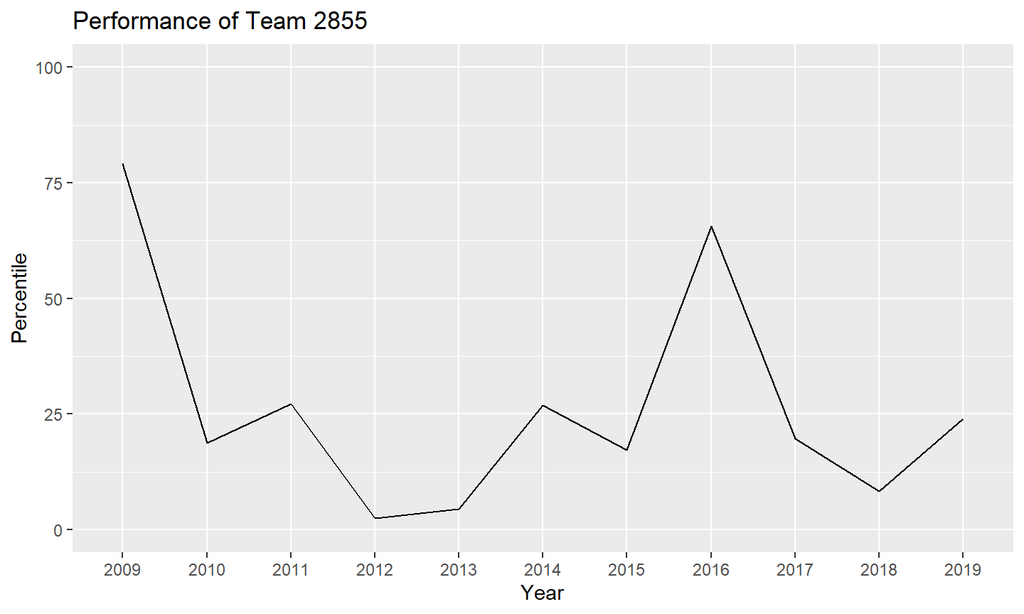

## 4. Top Performing Teams of All Time

| Team # | Nickname | Rookie Year | Years Competed | State/Province | Average Performance |
| --- | --- | --- | --- | --- | --- |
| 2056 | OP Robotics | 2007 | 14 | Ontario | 99.90801 |
| 2970 | eSchool eBots | 2009 | 1 | WI | 98.86567 |
| 5406 | Celt-X | 2015 | 6 | Ontario | 98.64966 |
| 2098 | Bulldogs | 2007 | 1 | GA | 98.45560 |
| 7457 | suPURDUEper Robotics | 2019 | 2 | Indiana | 97.89894 |
| 254 | The Cheesy Poofs | 1999 | 22 | California | 97.10775 |
| 1114 | Simbotics | 2003 | 18 | Ontario | 96.99516 |
| 3683 | Team DAVE | 2011 | 10 | Ontario | 96.98346 |
| 67 | The HOT Team | 1997 | 24 | Michigan | 96.91468 |
| 4414 | HighTide | 2012 | 2 | California | 96.80851 |
| 2753 | Team Overdrive | 2009 | 2 | NJ | 96.71322 |
| 7553 | OSTC - SWEET BOTS | 2019 | 2 | Michigan | 96.67553 |
| 5184 | TITANICS | 2014 | 1 | Alberta | 96.55172 |
| 4678 | CyberCavs | 2013 | 8 | Ontario | 96.19824 |
| 782 | Kilowatts | 2002 | 3 | CT | 96.15072 |

## 5. Performance of Longest Competing Teams

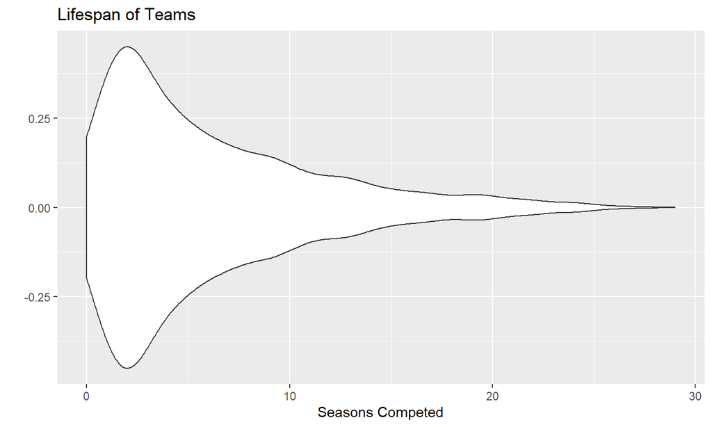

## 5. Performance of Longest Competing Teams

Defining experience as number of seasons completed versus number of matches played

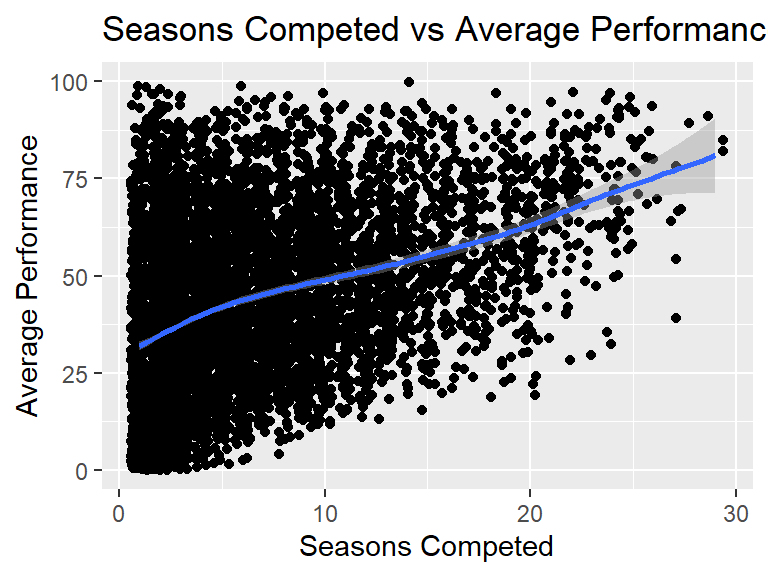

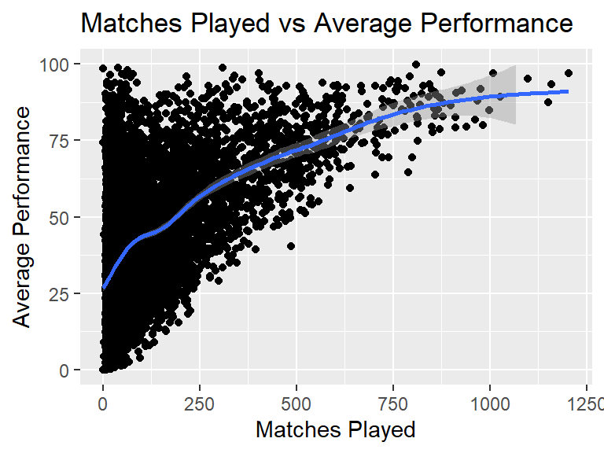

## Conclusion

- A more experienced team performs better in competition
- It is tough to quantify the effect of experience on performance
- A team must be successful to become experienced (seasons completed or matches played)